# Homework 6

Yuanji Sun

November 5, 2017

# Report process

1. Problems I ran into
   - I didn’t realize that Google sets limits to the database usage at the very beginning. My code failed because of this reason. Now the problem is fixed by only sending the first 10 rows to `revgeocode()`.
   - It is quite difficult to understand when I should use `~` to call a function inside of another function. I also spent a long time figuring out when I should add `.`, such as `revgeocode(c(.x,.y))` vs `revgeocode(c(x,y))`.
   - I ran into difficulty in telling the difference between `%>%` and `%$%`. This is solved by Googling.
   - It is quite difficult to subset a pattern from a string. I thought it was easy but I was wrong. The best way to solve this problem is to try by myself and Google it when having difficulty.
   - Another difficult issue is to understand the error message in RStudio. Sometimes it doesn’t make any sense. If I expand the message, I find that I cannot understand them at all. So I fix bugs in a slow way.
   - I am confused which library is in which package. So I loaded almost all potential useful packages.
2. Useful rescources
   - Lecture notes & course website
   - Website: https://stackoverflow.com
   - Google
   - Book: R for Data Science
3. Conclusion

This homework is not easy. Although many problems occurred, I learned a lot from debudding. By doing extra exercise, I am more clear about the skills discussed in lectures.

# Preparation: load libraries

```r
library(tidyverse)
library(stringr)
library(gapminder)
library(ggmap)
library(purrr)
library(repurrrsive)
```

```r
library(ggplot2)
library(dplyr)
library(robustbase)
library(listviewer)
```

# Overview

Pick (at least) two of the six (numbered) topics below and do one of the exercise prompts listed, or something comparable using your dataset of choice.

**I selected 5 questions to practise.**

# Part 1. Writing functions

Pick one:

- Write one (or more) functions that do something useful to pieces of the Gapminder or Singer data. It is logical to think about computing on the mini-data frames corresponding to the data for each specific country, location, year, band, album, … This would pair well with the prompt below about working with a nested data frame, as you could apply your function there.
  - Make it something you can’t easily do with built-in functions. Make it something that’s not trivial to do with the simple `dplyr` verbs. The linear regression function presented here is a good starting point. You could generalize that to do quadratic regression (include a squared term) or use robust regression, using `MASS::rlm()` or `robustbase::lmrob()`.
- If you plan to complete the homework where we build an R package, write a couple of experimental functions exploring some functionality that is useful to you in real life and that might form the basis of your personal package.

Answer:

Since we have not studied R package, I would like to write a function for the first question.

Level 1: The function is used to establish a **robust regression** model and calculate the coefficients of life expectancy on year of a selected country. The default offset is 1952, and the function should return the coefficients once the input (country) is provided. The data filteration and other work are finished inside of the funtion.

```r
# Write the function
lifeExp2year_1 <- function(country_input, offset = 1952) {
        data <- filter(gapminder, country == country_input)
        model <- lmrob(lifeExp ~ I(year - offset), data)
        setNames(coef(model), c("intercept", "slope"))
}

# Test on several countries
lifeExp2year_1("China")
```

```
##  intercept      slope
## 56.3265111  0.3095418
```

```r
lifeExp2year_1("France")
```

```
##  intercept      slope
## 67.8006431  0.2382475
```

```r
lifeExp2year_1("Canada")
```

```
##  intercept      slope
## 68.8850976  0.2187463
```

Level 2: What if I entered a wrong country name? I want to get a meaningful warning or error message rather than the default one given by RStudio. Here is the Version 2 of the function above.

```r
# Write the function
lifeExp2year_2 <- function(country_input, offset = 1952) {
        if(!country_input %in% gapminder$country) {
                warning('Warning: Invalid country name. Please try again. \n')
                stop
        }
        data <- filter(gapminder, country == country_input)
        model <- lmrob(lifeExp ~ I(year - offset), data)
        setNames(coef(model), c("intercept", "slope"))
}

# Test on wrong country name (Spell in a wrong way to test the warning/error message)
lifeExp2year_2("Canadian")
```

```
## Warning in lifeExp2year_2("Canadian"): Warning: Invalid country name. Please try again.
```

```
## intercept     slope
##        NA        NA
```

Level 3: It would be great to get an output of the linear regression figure so that I can check whether the regression model is good or not. Using a figure is the easiest way to do so. Here is the Version 3 of the function above. A title is added to each figure using the country name (input).

```
##  intercept      slope
## 56.3265111  0.3095418
```

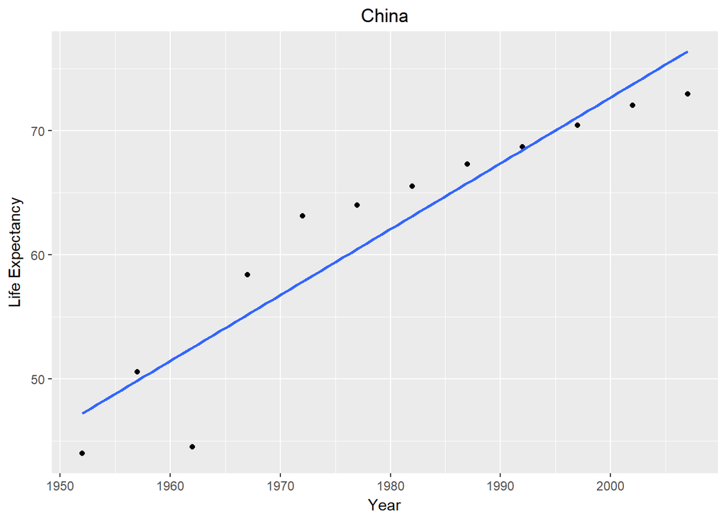

```r
# Write the function
lifeExp2year_3 <- function(country_input, offset = 1952) {
        if(!country_input %in% gapminder$country) {
                stop('Invalid country name. Please try again.')
        }
        data <- filter(gapminder, country == country_input)
        model <- lmrob(lifeExp ~ I(year - offset), data)
        print(setNames(coef(model), c("intercept", "slope")))
        ggplot(data, aes(x = year, y = lifeExp)) +
                geom_point() + geom_smooth(method = "lm", se = FALSE) +
                labs(x="Year",y="Life Expectancy", title=country_input) +
                theme(plot.title = element_text(hjust=0.5))
}

# Test on wrong country name (Spell in a wrong way to test the warning/error message)
lifeExp2year_3("China")
```

```r
lifeExp2year_3("Canada")
```

```
##  intercept      slope
## 68.8850976  0.2187463
```

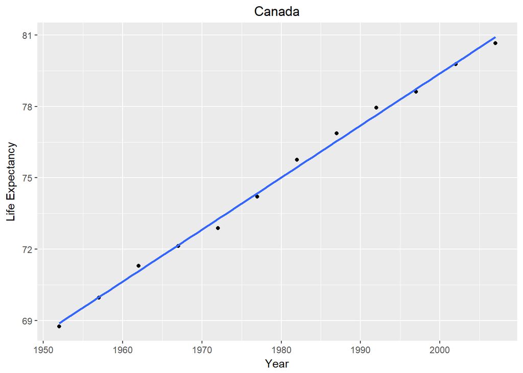

```r
lifeExp2year_3("Malaysia")
```

```
##  intercept      slope
## 51.5816161  0.4632449
```

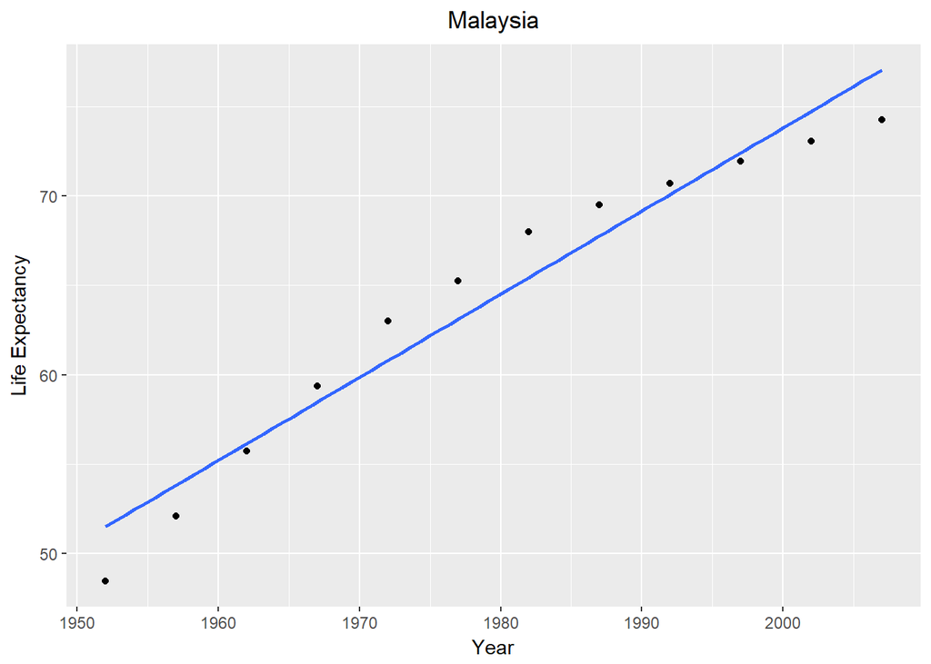

Level 4: I want to set up several models and compare all coefficients. Version 4 below will allow me to do this.

```r
# Write the function
lifeExp2year_4 <- function(country_input, offset = 1952) {
        if(!country_input %in% gapminder$country) {
                stop('Invalid country name. Please try again.')
        }
        data <- filter(gapminder, country == country_input)
        model_1 <- lmrob(lifeExp ~ I(year - offset), data)
        print(setNames(coef(model_1), c("intercept_1", "slope_1")))
        model_2 <- lm(lifeExp ~ I(year - offset) +I(year^2), data)
        print(setNames(coef(model_2), c("intercept_2", "slope_2")))
        model_3 <- lm(lifeExp ~ I(year - offset) +I(year^2) + I(year^3), data)
        print(setNames(coef(model_3), c("intercept_3", "slope_3")))
}

lifeExp2year_4("China")
```

```
## intercept_1     slope_1
##  56.3265111   0.3095418
##   intercept_2       slope_2          <NA>
##  3.284112e+04  3.460852e+01 -8.607680e-03
##   intercept_3       slope_3          <NA>          <NA>
##  2.160014e+04  2.590959e+01 -4.212975e-03 -7.400363e-07
```

# Part 2. Work with the `singer` data

The `singer_location` dataframe in the `singer` package contains geographical information stored in two different formats: 1. as a (dirty!) variable named `city`; 2. as a latitude / longitude pair (stored in `latitude`, `longitude` respectively). The function `revgeocode` from the `ggmap` library allows you to retrieve some information for a pair (vector) of longitude, latitude (warning: notice the order in which you need to pass lat and long). Read its manual page.

1. Use `purrr` to map latitude and longitude into human readable information on the band’s origin places. Notice that `revgeocode(... , output = "more")` outputs a dataframe, while `revgeocode(... , output = "address")` returns a string: you have the option of dealing with nested dataframes.

You will need to pay attention to two things: + Not all of the track have a latitude and longitude: what can we do with the missing information? (filtering, …) + Not all of the time we make a research through `revgeocode()` we get a result. What can we do to avoid those errors to bite us? (look at `possibly()` in `purrr`…)

2. Try to check wether the place in `city` corresponds to the information you retrieved.
3. If you still have time, you can go visual: give a look to the library `leaflet` and plot some information about the bands. A snippet of code is provided below. `singer_locations %>%` `leaflet() %>%` `addTiles() %>%` `addCircles(popup = ~artist_name)`

Answer:

The first step is to load the data and library. I downloaded the dataset and loaded it manually.

```r
load("singer_locations.RData")
```

Check the documentation to understand `revgeocode`. According to online information (not in the R documentation), longitude comes first folllowed by latitude.

```r
?revgeocode
```

```
## starting httpd help server ... done
```

Step 1: Convert latitude and longitude into human readable information. First, I use filter to remove all `NA` values of latitude and longitude. Since the final result is quite long, only the first 10 rows are displayed.

```r
library(magrittr)
location_Google_test <- singer_locations %>%
        filter(!is.na(latitude) & !is.na(longitude)) %>%
        # select(longitude, latitude) %>%
        head(n=10) %$%
        map2(longitude, latitude, ~ revgeocode(c(.x,.y), output="more")) %>%
        bind_rows()

knitr::kable(location_Google_test)
```

| address | street_number | route | neighborhood | locality | administrative_area_level_2 | administrative_area_level_1 | country | postal_code | political | administrative_area_level_3 | postal_code_suffix |
| --- | --- | --- | --- | --- | --- | --- | --- | --- | --- | --- | --- |
| 123-135 North LaSalle Street, Chicago, IL 60602, USA | 123-135 | North LaSalle Street | Chicago Loop | Chicago | Cook County | Illinois | United States | 60602 | NA | NA | NA |
| 80 Chambers St, New York, NY 10007, USA | 80 | Chambers Street | Lower Manhattan | New York | New York County | New York | United States | 10007 | Manhattan | NA | NA |
| 2-44 Michigan Ave, Detroit, MI 48226, USA | 2-44 | Michigan Avenue | Downtown | Detroit | Wayne County | Michigan | United States | 48226 | NA | NA | NA |
| 997 Sand Ridge Rd, Howard, PA 16841, USA | 997 | Sand Ridge Road | NA | Howard | Centre County | Pennsylvania | United States | 16841 | NA | Marion Township | NA |
| 349 3rd Street, Oxnard, CA 93030, USA | 349 | 3rd Street | Wilson | Oxnard | Ventura County | California | United States | 93030 | NA | NA | NA |
| An der Evangelischen Kirche 6, 53113 Bonn, Germany | 6 | An der Evangelischen Kirche | NA | Bonn | Köln | Nordrhein-Westfalen | Germany | 53113 | NA | NA | NA |
| Unnamed Road, Hawaii, USA | NA | Unnamed Road | NA | NA | Hawaii County | Hawaii | United States | NA | NA | NA | NA |
| 262-298 W 1st St, Los Angeles, CA 90012, USA | 262-298 | West 1st Street | Central LA | Los Angeles | Los Angeles County | California | United States | 90012 | NA | NA | NA |
| 215 Arthur Kill Rd, Staten Island, NY 10306, USA | 215 | Arthur Kill Road | NA | NA | Richmond County | New York | United States | 10306 | Staten Island | NA | 1166 |
| Pacific Hwy W, Portland, OR 97201, USA | NA | Pacific Highway West | Southwest Portland | Portland | Multnomah County | Oregon | United States | 97201 | NA | NA | NA |

```r
jsonedit(location_Google_test)
```

[interactive chart not shown]

The results above looks good but that is only the first 10 records. Since not all of the time we make a research through `revgeocode()` we get a result, I optimized the code below using a combination of `possibly()` and `revgeocode()` to avoid any error. I defined a new function called `poss_rgc` to put them together and called this function in the code.

**(Sorry, the output here is the same as the one above since only the first 10 rows are used due to the daily limits set by Google.)**

```r
library(magrittr)

poss_rgc <- possibly(~ revgeocode(c(.x,.y), output="more"), "NA_character_", quiet = TRUE)

location_Google <- singer_locations %>%
        filter(!is.na(latitude) & !is.na(longitude)) %>%
        select(longitude, latitude) %>%
        head(n=10) %$%
        map2(longitude, latitude, poss_rgc) %>%
        bind_rows()

knitr::kable(location_Google)
```

| address | street_number | route | neighborhood | locality | administrative_area_level_2 | administrative_area_level_1 | country | postal_code | political | administrative_area_level_3 | postal_code_suffix |
| --- | --- | --- | --- | --- | --- | --- | --- | --- | --- | --- | --- |
| 123-135 North LaSalle Street, Chicago, IL 60602, USA | 123-135 | North LaSalle Street | Chicago Loop | Chicago | Cook County | Illinois | United States | 60602 | NA | NA | NA |
| 80 Chambers St, New York, NY 10007, USA | 80 | Chambers Street | Lower Manhattan | New York | New York County | New York | United States | 10007 | Manhattan | NA | NA |
| 2-44 Michigan Ave, Detroit, MI 48226, USA | 2-44 | Michigan Avenue | Downtown | Detroit | Wayne County | Michigan | United States | 48226 | NA | NA | NA |
| 997 Sand Ridge Rd, Howard, PA 16841, USA | 997 | Sand Ridge Road | NA | Howard | Centre County | Pennsylvania | United States | 16841 | NA | Marion Township | NA |
| 349 3rd Street, Oxnard, CA 93030, USA | 349 | 3rd Street | Wilson | Oxnard | Ventura County | California | United States | 93030 | NA | NA | NA |
| An der Evangelischen Kirche 6, 53113 Bonn, Germany | 6 | An der Evangelischen Kirche | NA | Bonn | Köln | Nordrhein-Westfalen | Germany | 53113 | NA | NA | NA |
| Unnamed Road, Hawaii, USA | NA | Unnamed Road | NA | NA | Hawaii County | Hawaii | United States | NA | NA | NA | NA |
| 262-298 W 1st St, Los Angeles, CA 90012, USA | 262-298 | West 1st Street | Central LA | Los Angeles | Los Angeles County | California | United States | 90012 | NA | NA | NA |
| 215 Arthur Kill Rd, Staten Island, NY 10306, USA | 215 | Arthur Kill Road | NA | NA | Richmond County | New York | United States | 10306 | Staten Island | NA | 1166 |
| Pacific Hwy W, Portland, OR 97201, USA | NA | Pacific Highway West | Southwest Portland | Portland | Multnomah County | Oregon | United States | 97201 | NA | NA | NA |

```r
jsonedit(location_Google)
```

[interactive chart not shown]

Step 2: check wether the place in `city` corresponds to the information you retrieved. By observing the result above, there is a column called `locality`, which contains the city name. So I am going to compare `city` in `singer_locations` with `locality` in `location_Google`. However, there are two aspects need to be dealt with.

1. The city name in `singer_locations` is a combination of city and state, such as “Chicago, IL”. Thus, I need to separate them and get the city name only.
2. Since I removed all `NA` in the question above, I also need to remove all rows with `NA` in latitude or longitude. Otherwise, the results cannot be matched.

```r
# Part 1: Get city name from singer_locations
  # Select data by removing NA in latitude and longitude
city_state <- singer_locations %>%
        filter(!is.na(latitude) & !is.na(longitude))

# Seperate the city from state and get the result of city only
(city_from_singer <- str_split(city_state$city, pattern=", ") %>%
        head(n=10) %>%
        map(1))
```

```
## [[1]]
## [1] "Chicago"
##
## [[2]]
## [1] "New York"
##
## [[3]]
## [1] "Detroit"
##
## [[4]]
## [1] "Pennsylvania"
##
## [[5]]
## [1] "Oxnard"
##
## [[6]]
## [1] "Bonn"
##
## [[7]]
## [1] "Hawaii"
##
## [[8]]
## [1] "Los Angeles"
##
## [[9]]
## [1] "Staten Island"
##
## [[10]]
## [1] "Portland"
```

```r
# Part 2: Get city name from the result obtained from Google
(city_from_Google <- location_Google$locality)
```

```
##  [1] "Chicago"     "New York"    "Detroit"     "Howard"      "Oxnard"
##  [6] "Bonn"        NA            "Los Angeles" NA            "Portland"
```

```r
# Part 3: Compare both results
city_from_Google==city_from_singer
```

```
##  [1]  TRUE  TRUE  TRUE FALSE  TRUE  TRUE    NA  TRUE    NA  TRUE
```

Step 3: Visualization (`leaflet` should be installed in advance if it is not done so.) Instead of using default tile, I changed it to the tile provided by Esri. I did the same work as above: filter the gps data by removing all `NA`/invalid values and selet only the first 10 records for the map. Click on the marker to see the artist name.

```r
library(leaflet)
singer_locations %>%
        filter(!is.na(latitude) & !is.na(longitude)) %>%
        head(n=10) %>%
        leaflet() %>%
        addProviderTiles(providers$Esri.NatGeoWorldMap) %>%
        addMarkers(popup = ~ artist_name)
```

```
## Assuming 'longitude' and 'latitude' are longitude and latitude, respectively
```

[interactive chart not shown]

# Part 3. Work with a list

Work through and write up a lesson from the purrr tutorial:

- Trump Android Tweets
- Simplifying data from a list of GitHub users

Answer:

I think this question asks me to write a summary of what I learned from the cases above.

**Simplifying data from a list of GitHub users**

1. `str()` is used to compactly display the structure of an arbitrary R object. There are several widely-used arguments in the funcion, which are shown below.
- `max.level`: maximal level of nesting which is applied for displaying nested structures, e.g., a list containing sub lists. The default value is `NA`, which will display all nesting levels.
- `list.len`: maximum number of list elements to display within a level. It is numeric.
2. In order to view the list interactively, `jsonedit(gh_users)` can be used which comes from the package `listviewer`.
3. Subset data from the list can be done using `map(.x, .f, ...)` from `purrr`. `.x` is the list to be viewed and `.f` is the function to be apply to the list. There are two ways to set `.f`, (1) in the form of `function(x) x[["TEXT"]]`, and (2) `function(x) x[[i]]`.
4. It is a good idea to use **type-specific map** to get the output in the form of atomic vector, such as `map_chr()` and `map_dbl()`.
5. If multiple values need to be extracted, we can combine variable names using `c()`. A good example is `gh_users[[3]][c("name", "login", "id", "location")]`. It looks wired to use `[` but it works and there is no need to add `]`. Here is an example `map(gh_users,`[`, c("login", "name", "id", "location"))`.
6. It is also possible to use vector input to extract shortcuts. The key point is that the j-th element addresses the j-th level of the hierarchy. For instance, `map_chr(gh_repos, c(1, 3))` will return the full name (element 3) of the first repository listed for each user.
7. If we want to get a list inside the dataframe, `tibble::enframe()` can be used. The basic sytax is `enframe(x, name = "name", value = "value")`, in which `name` and `value` are names of the columns that store the names and values.
8. One last point is that, remember to use `%>%` which will make life eaiser.

**Trump Android Tweets**

There are a few new things that benefit me a lot.

1. `gregexpr()`: the purpose is pattern matching and replacement. There are many usages but the most common syntax is `gregexpr(pattern, x)`. `x` is a character vector where matches are sought, or an object which can be coerced by `as.character` to a character vector. `pattern` is the character string containing a regular expression.
2. `substring()`: it is used to extract or replace substrings in a character vector. The basic syntax is `substr(x, start, stop)` in which `x` is a character vector, `start` and `stop` are the first and last elements to be replaced.
3. There are three types of functions, **pre-defined custom function** (e.g. `ml <- function(x) attr(x, which = "match.length")`), **anonymous function** (e.g. `map(matches, ~ attr(.x, which = "match.length"))`) and *pre-existing function* (e.g. `match_length <- map(matches, attr, which = "match.length")`).

# Part 4. Work with a nested data frame

Create a nested data frame and map a function over the list column holding the nested data. Use list extraction or other functions to pull interesting information out of these results and work your way back to a simple data frame you can visualize and explore.

- Nest the data by country (and continent).
- Fit a model of life expectancy against year. Possibly quadratic, possibly robust (see above prompt re: function writing).

Answer:

I selected the several questions above to practise. First, I created a nested dataframe by `country` and `continent` seperately.

```r
# Nest by country
(gapminder_nest_country <- gapminder %>%
         group_by(country) %>%
         nest())
```

```
## # A tibble: 142 x 2
##        country              data
##         <fctr>            <list>
##  1 Afghanistan <tibble [12 x 5]>
##  2     Albania <tibble [12 x 5]>
##  3     Algeria <tibble [12 x 5]>
##  4      Angola <tibble [12 x 5]>
##  5   Argentina <tibble [12 x 5]>
##  6   Australia <tibble [12 x 5]>
##  7     Austria <tibble [12 x 5]>
##  8     Bahrain <tibble [12 x 5]>
##  9  Bangladesh <tibble [12 x 5]>
## 10     Belgium <tibble [12 x 5]>
## # ... with 132 more rows
```

```r
# Nest by continent
(gapminder_nest_continent <- gapminder %>%
        group_by(continent) %>%
        nest())
```

```
## # A tibble: 5 x 2
##   continent               data
##      <fctr>             <list>
## 1      Asia <tibble [396 x 5]>
## 2    Europe <tibble [360 x 5]>
## 3    Africa <tibble [624 x 5]>
## 4  Americas <tibble [300 x 5]>
## 5   Oceania  <tibble [24 x 5]>
```

```r
# Nest by both country and continent
(gapminder_both <- gapminder %>%
        group_by(continent, country) %>%
        nest())
```

```
## # A tibble: 142 x 3
##    continent     country              data
##       <fctr>      <fctr>            <list>
##  1      Asia Afghanistan <tibble [12 x 4]>
##  2    Europe     Albania <tibble [12 x 4]>
##  3    Africa     Algeria <tibble [12 x 4]>
##  4    Africa      Angola <tibble [12 x 4]>
##  5  Americas   Argentina <tibble [12 x 4]>
##  6   Oceania   Australia <tibble [12 x 4]>
##  7    Europe     Austria <tibble [12 x 4]>
##  8      Asia     Bahrain <tibble [12 x 4]>
##  9      Asia  Bangladesh <tibble [12 x 4]>
## 10    Europe     Belgium <tibble [12 x 4]>
## # ... with 132 more rows
```

For the function of the model fit, I modified the `lifeExp2year_1` in the previous question to make sure that it can deal with nested data input. By comparing with the results in Part 1, we can see that the results are the same, meaning this function works properly.

```r
# Write the function
lifeExp2year_5 <- function(country_input, offset = 1952) {
        data <- data.frame(filter(gapminder_both, country == country_input)[[3]])
        model <- lmrob(lifeExp ~ I(year - offset), data)
        setNames(coef(model), c("intercept", "slope"))
}

# Test on several countries
lifeExp2year_5("China")
```

```
##  intercept      slope
## 56.3265111  0.3095418
```

```r
lifeExp2year_5("France")
```

```
##  intercept      slope
## 67.8006431  0.2382475
```

```r
lifeExp2year_5("Canada")
```

```
##  intercept      slope
## 68.8850976  0.2187463
```

# Part 5. Character data

Read and work the exercises in the Strings chapter or R for Data Science.

- Question 1: Use `str_length()` and `str_sub()` to extract the middle character from a string. What will you do if the string has an even number of characters?
- Question 2: What does `str_wrap()` do? When might you want to use it?
- Question 3: What patterns will the regular expression `\..\..\..` match? How would you represent it as a string?
- Question 4: How would you match the literal string `"$^$"`?
- Question 5: Create a regular expression that will match telephone numbers as commonly written in your country.
- Question 6: Describe the equivalents of `?`, `+`, `*` in `{m,n}` form.

Answer:

Since I have spent a very long time on this homework and did a lot of extra exercise, I only finish 6 questions here.

Question 1: It is difficult to have even number of characters. However, I used length/2 and round it. Then pass the result to the `str_sub()` and set the start & end point to be length/2. It works.

```r
string_1 <- c("apple", "banana", "dog", "cate")
length_1 <- str_length(string_1)
middle <- ceiling(length_1 / 2)
str_sub(string_1, middle, middle)
```

```
## [1] "p" "n" "o" "a"
```

Question 2:

`str_wrap()` wraps strings into nicely formatted paragraphs. It is helpful when dealing with a long text string. The syntax is `str_wrap(string, width = 80, indent = 0, exdent = 0)`.

Question 3:

I think the pattern matched here will be any characters with a dot at the beginning. The pattern (string) will be repeated 3 times.

Question 4:

I can match the string `"$^$"` using the code below.

```r
str_view(c("$^$"), "^\\$\\^\\$$")
```

[interactive chart not shown]

Question 5:

Here is an example to match telephone numbers in the format used in Canada.

```r
x <- c("604-888-1234")
str_view(x, "\\n\\n\\n-\\n\\n\\n-\\n\\n\\n\\n")
```

[interactive chart not shown]

Question 6:

I am not sure about this question. I think `?` should be equal to `{,1},`+`may be equal to`{1,}. I don’t know what is `*` equal to.

[This is the end of Homework 6.]